# Getting started with `EpiAware`

This tutorial introduces the basic functionality of `EpiAware`. `EpiAware` is a package for making inferences on epidemiological case/determined infection data using a model-based approach.

It is common to conceptualise the generative process of public health data, e.g a time series of reported cases of an infectious pathogen, in a modular way. For example, it is common to abstract the underlying latent infection process away from downstream issues of observation, or to treat quanitites such as the time-varying reproduction number as being itself generated as a random process.

`EpiAware` is built using the [`DynamicPPL`](https://github.com/TuringLang/DynamicPPL.jl) probabilistic programming domain-specific language, which is part of the [`Turing`](https://turinglang.org/dev/docs/using-turing/guide/) PPL. The structural concept behind `EpiAware` is that each module of an epidemiological model is a self-contained `Turing`[`Model`](https://turinglang.org/DynamicPPL.jl/stable/api/#DynamicPPL.Model-Tuple{}); that is each module is an object that can be conditioned on observable data and sampled from. A complete `EpiAware` model is the composition of these objects using the [`@submodel`](https://turinglang.org/DynamicPPL.jl/stable/api/#DynamicPPL.@submodel) macro.

## Example: Early COVID-19 case data in South Korea

To demonstrate `EpiAware` we largely recreate an epidemiological model presented in [On the derivation of the renewal equation from an age-dependent branching process: an epidemic modelling perspective, *Mishra et al* (2020)](https://arxiv.org/abs/2006.16487). *Mishra et al* consider test-confirmed cases of COVID-19 in South Korea between January to July 2020. The components of the epidemilogical model they consider are:

- The log-time varying reproductive number $\log R_t$ is modelled as an AR(2) process.
- The latent infection ($I_t$) generating process is a renewal model:

$$I_t = \mu_t + R_t \sum_{s\geq 1} I_{t-s} g_s.$$

Where $g_t$ is a daily discretisation of the probability mass function of an estimated serial interval distribution:

$$G \sim \text{Gamma}(6.5,0.62).$$

And $\mu_t$ is an external importation of infection process.

- Observed cases $C_t$ are distributed around latent infections with negative binomial errors:

$$C_t \sim \text{NegBin}(\text{mean} = I_t,~ \text{overdispersion} = \phi).$$

In the examples below we are going to largely recreate the *Mishra et al* model, whilst emphasing that each component of the overall epidemiological model is, itself, a stand alone model that can be sampled from.

```
TaskLocalRNG()
```

### Time-varying reproduction number as a `LatentModel` type

`EpiAware` exposes a `LatentModel` type system; the purpose of which is to define stochastic processes which can be interpreted as generating time-varying parameters/quantities of interest.

In the *Mishra et al* model the log-time varying reproductive number is *a priori* assumed to evolve as an auto-regressive process, AR(2):

$$\begin{align} Z_t &= \log R_t, \\ Z_t &= \rho_1 Z_{t-1} + \rho_2 Z_{t-2} + \epsilon_t, \\ \epsilon_t &\sim \text{Normal}(0, \sigma). \end{align}$$

`EpiAware` gives a concrete subtype `AR <: AbstractLatentModel` which defines this behaviour of the latent model. The user can supply the priors for $\rho_1,\rho_2$, wich we call `damp_priors`, as well as for $\sigma$ (`std_prior`) and the initial values $Z_1, Z_2$ (`init_priors`).

```julia
ar = AR(
    damp_priors = [truncated(Normal(0.8, 0.05), 0, 1),
        truncated(Normal(0.05, 0.05), 0, 1)],
    std_prior = HalfNormal(1.0),
    init_priors = [Normal(-1.0, 0.1), Normal(-1.0, 0.1)]
)
```

```
AR{Product{Continuous, Truncated{Normal{Float64}, Continuous, Float64, Float64, Float64}, Vector{Truncated{Normal{Float64}, Continuous, Float64, Float64, Float64}}}, HalfNormal{Float64}, DistributionsAD.TuringScalMvNormal{Vector{Float64}, Float64}, Int64}(Distributions.Product{Distributions.Continuous, Distributions.Truncated{Distributions.Normal{Float64}, Distributions.Continuous, Float64, Float64, Float64}, Vector{Distributions.Truncated{Distributions.Normal{Float64}, Distributions.Continuous, Float64, Float64, Float64}}}(v=Truncated{Normal{Float64}, Continuous, Float64, Float64, Float64}[Truncated(Distributions.Normal{Float64}(μ=0.8, σ=0.05); lower=0.0, upper=1.0), Truncated(Distributions.Normal{Float64}(μ=0.05, σ=0.05); lower=0.0, upper=1.0)]), HalfNormal{Float64}(μ=1.0), DistributionsAD.TuringScalMvNormal{Vector{Float64}, Float64}(m=[-1.0, -1.0], σ=0.1), 2)
```

The priors here are based on *Mishra et al*, note that we have decreased the *a priori* belief in the correlation parameter $\rho_1$.

##### `Turing` model interface

As mentioned above, we can use this instance of the `AR` latent model to construct a `Turing``Model` which implements the probabilistic behaviour determined by `ar`.

We do this with the constructor function `generate_latent` which combines `ar` with a number of time steps to generate for (in this case we choose 30).

```julia
ar_mdl = generate_latent(ar, 30)
```

```
Model{typeof(generate_latent), (:latent_model, :n), (), (), Tuple{AR{Product{Continuous, Truncated{Normal{Float64}, Continuous, Float64, Float64, Float64}, Vector{Truncated{Normal{Float64}, Continuous, Float64, Float64, Float64}}}, HalfNormal{Float64}, DistributionsAD.TuringScalMvNormal{Vector{Float64}, Float64}, Int64}, Int64}, Tuple{}, DefaultContext}(EpiAware.EpiAwareBase.generate_latent, (latent_model = AR{Product{Continuous, Truncated{Normal{Float64}, Continuous, Float64, Float64, Float64}, Vector{Truncated{Normal{Float64}, Continuous, Float64, Float64, Float64}}}, HalfNormal{Float64}, DistributionsAD.TuringScalMvNormal{Vector{Float64}, Float64}, Int64}(Distributions.Product{Distributions.Continuous, Distributions.Truncated{Distributions.Normal{Float64}, Distributions.Continuous, Float64, Float64, Float64}, Vector{Distributions.Truncated{Distributions.Normal{Float64}, Distributions.Continuous, Float64, Float64, Float64}}}(v=Truncated{Normal{Float64}, Continuous, Float64, Float64, Float64}[Truncated(Distributions.Normal{Float64}(μ=0.8, σ=0.05); lower=0.0, upper=1.0), Truncated(Distributions.Normal{Float64}(μ=0.05, σ=0.05); lower=0.0, upper=1.0)]), HalfNormal{Float64}(μ=1.0), DistributionsAD.TuringScalMvNormal{Vector{Float64}, Float64}(m=[-1.0, -1.0], σ=0.1), 2), n = 30), NamedTuple(), DefaultContext())
```

We can sample from this model, which is useful for model diagnostic and prior predictive checking.

[figure not shown]

And we can sample from this model with some parameters conditioned, for example with $\sigma = 0$. In this case the AR process is an initial perturbation model with return to baseline.

```julia
cond_ar_mdl = ar_mdl | (σ_AR = 0.0,)
```

```
Model{typeof(generate_latent), (:latent_model, :n), (), (), Tuple{AR{Product{Continuous, Truncated{Normal{Float64}, Continuous, Float64, Float64, Float64}, Vector{Truncated{Normal{Float64}, Continuous, Float64, Float64, Float64}}}, HalfNormal{Float64}, DistributionsAD.TuringScalMvNormal{Vector{Float64}, Float64}, Int64}, Int64}, Tuple{}, ConditionContext{@NamedTuple{σ_AR::Float64}, DefaultContext}}(EpiAware.EpiAwareBase.generate_latent, (latent_model = AR{Product{Continuous, Truncated{Normal{Float64}, Continuous, Float64, Float64, Float64}, Vector{Truncated{Normal{Float64}, Continuous, Float64, Float64, Float64}}}, HalfNormal{Float64}, DistributionsAD.TuringScalMvNormal{Vector{Float64}, Float64}, Int64}(Distributions.Product{Distributions.Continuous, Distributions.Truncated{Distributions.Normal{Float64}, Distributions.Continuous, Float64, Float64, Float64}, Vector{Distributions.Truncated{Distributions.Normal{Float64}, Distributions.Continuous, Float64, Float64, Float64}}}(v=Truncated{Normal{Float64}, Continuous, Float64, Float64, Float64}[Truncated(Distributions.Normal{Float64}(μ=0.8, σ=0.05); lower=0.0, upper=1.0), Truncated(Distributions.Normal{Float64}(μ=0.05, σ=0.05); lower=0.0, upper=1.0)]), HalfNormal{Float64}(μ=1.0), DistributionsAD.TuringScalMvNormal{Vector{Float64}, Float64}(m=[-1.0, -1.0], σ=0.1), 2), n = 30), NamedTuple(), ConditionContext((σ_AR = 0.0,), DynamicPPL.DefaultContext()))
```

[figure not shown]

In this note, we are going to treat $R_t$ as varying every two days. The reason for this is to 1) reduce the effective number of parameters, and 2) showcase the `BroadcastLatentModel` wrapper.

In `EpiAware` we set this behaviour by wrapping a `LatentModel` in a `BroadcastLatentModel`. This allows us to set the broadcasting period and type. In this case we broadcast each latent process value over $2$ days in a `RepeatBlock`.

```julia
twod_ar = BroadcastLatentModel(ar, 2, RepeatBlock())
```

```
BroadcastLatentModel{AR{Product{Continuous, Truncated{Normal{Float64}, Continuous, Float64, Float64, Float64}, Vector{Truncated{Normal{Float64}, Continuous, Float64, Float64, Float64}}}, HalfNormal{Float64}, DistributionsAD.TuringScalMvNormal{Vector{Float64}, Float64}, Int64}, Int64, RepeatBlock}(AR{Product{Continuous, Truncated{Normal{Float64}, Continuous, Float64, Float64, Float64}, Vector{Truncated{Normal{Float64}, Continuous, Float64, Float64, Float64}}}, HalfNormal{Float64}, DistributionsAD.TuringScalMvNormal{Vector{Float64}, Float64}, Int64}(Distributions.Product{Distributions.Continuous, Distributions.Truncated{Distributions.Normal{Float64}, Distributions.Continuous, Float64, Float64, Float64}, Vector{Distributions.Truncated{Distributions.Normal{Float64}, Distributions.Continuous, Float64, Float64, Float64}}}(v=Truncated{Normal{Float64}, Continuous, Float64, Float64, Float64}[Truncated(Distributions.Normal{Float64}(μ=0.8, σ=0.05); lower=0.0, upper=1.0), Truncated(Distributions.Normal{Float64}(μ=0.05, σ=0.05); lower=0.0, upper=1.0)]), HalfNormal{Float64}(μ=1.0), DistributionsAD.TuringScalMvNormal{Vector{Float64}, Float64}(m=[-1.0, -1.0], σ=0.1), 2), 2, RepeatBlock())
```

[figure not shown]

## The Renewal model as an `EpiModel` type

`EpiAware` has an `EpiModel` type system which we use to set the behaviour of the latent infection model. In this case we want to implement a renewal model.

To construct an `EpiModel` we need to supply some fixed data for the model contained in an `EpiData` object. The `EpiData` constructor performs double interval censoring to convert our *continuous* estimate of the generation interval into a discretized version $g_t$. We also implement right truncation using the keyword `D_gen`.

```julia
truth_GI = Gamma(6.5, 0.62)
```

```
Distributions.Gamma{Float64}(α=6.5, θ=0.62)
```

```julia
model_data = EpiData(gen_distribution = truth_GI,
    D_gen = 14.0)
```

```
EpiData{Float64, typeof(exp)}([0.026361445124839917, 0.13900693991843663, 0.24743431164565052, 0.24509079663876318, 0.17121566842304276, 0.09526380990753629, 0.045216898823172424, 0.019095294222773795, 0.0073745251642216925, 0.002654116799153551, 0.0009022931501105248, 0.00029265202298423503, 9.124815931444699e-5], 13, exp)
```

[figure not shown]

The user also needs to specify a prior for the log incidence at time zero, $\log I_0$. The initial *history* of latent infections $I_{-1}, I_{-2},\dots$ is constructed as

$$I_t = e^{rt} I_0,\qquad t = 0, -1, -2,...$$

Where the exponential growth rate $r$ is determined by the initial reproductive number $R_1$ via the solution to the implicit equation,

$$R_1 = 1 \Big{/} \sum_{t\geq 1} e^{-rt} g_t$$

```julia
log_I0_prior = Normal(log(1.0), 1.0)
```

```
Distributions.Normal{Float64}(μ=0.0, σ=1.0)
```

```julia
epi = RenewalWithPopulation(model_data, log_I0_prior, 1e8)
```

```
RenewalWithPopulation{Normal{Float64}}(EpiData{Float64, typeof(exp)}([0.026361445124839917, 0.13900693991843663, 0.24743431164565052, 0.24509079663876318, 0.17121566842304276, 0.09526380990753629, 0.045216898823172424, 0.019095294222773795, 0.0073745251642216925, 0.002654116799153551, 0.0009022931501105248, 0.00029265202298423503, 9.124815931444699e-5], 13, exp), Distributions.Normal{Float64}(μ=0.0, σ=1.0), 1.0e8)
```

*NB: We don't implement a background infection rate in this model.*

##### `Turing` model interface

As mentioned above, we can use this instance of the `Renewal` latent infection model to construct a `Turing``Model` which implements the probabilistic behaviour determined by `epi`.

We do this with the constructor function `generate_latent_infs` which combines `epi` with a provided $\log R_t$ time series.

Here we choose an example where $R_t$ decreases from $R_t = 3$ to $R_t = 0.5$ over the course of 30 days.

```julia
R_t_fixed = [0.5 + 2.5 / (1 + exp(t - 15)) for t in 1:30]
```

```
30-element Vector{Float64}:
 2.9999979211799306
 2.9999943491892553
 2.9999846395634946
 2.99995824644538
 2.9998865053282437
 2.9996915135600344
 2.999161624673834
 ⋮
 0.500113494671756
 0.5000417535546202
 0.5000153604365055
 0.5000056508107448
 0.5000020788200692
 0.5000007647555673
```

```julia
latent_inf_mdl = generate_latent_infs(epi, log.(R_t_fixed))
```

```
Model{typeof(generate_latent_infs), (:epi_model, :_Rt), (), (), Tuple{RenewalWithPopulation{Normal{Float64}}, Vector{Float64}}, Tuple{}, DefaultContext}(EpiAware.EpiAwareBase.generate_latent_infs, (epi_model = RenewalWithPopulation{Normal{Float64}}(EpiData{Float64, typeof(exp)}([0.026361445124839917, 0.13900693991843663, 0.24743431164565052, 0.24509079663876318, 0.17121566842304276, 0.09526380990753629, 0.045216898823172424, 0.019095294222773795, 0.0073745251642216925, 0.002654116799153551, 0.0009022931501105248, 0.00029265202298423503, 9.124815931444699e-5], 13, exp), Distributions.Normal{Float64}(μ=0.0, σ=1.0), 1.0e8), _Rt = [1.0986115957278464, 1.098610405062754, 1.0986071685094998, 1.0985983707197156, 1.0985744563952262, 1.098509454567543, 1.0983327911702674, 1.097852790994088, 1.09654964358037, 1.0930193012626002  …  -0.6808598639891831, -0.6886022683659516, -0.6914718340845708, -0.6925303979295329, -0.6929202169746165, -0.6930636769372295, -0.6931164601588107, -0.6931358790023187, -0.6931430229284499, -0.6931456510499804]), NamedTuple(), DefaultContext())
```

[figure not shown]

### Negative Binomial Observations as an `ObservationModel` type

In *Mishra et al* latent infections were assumed to occur on their observation day with negative binomial errors, this motivates using the serial interval (the time between onset of symptoms of a primary and secondary case) rather than generation interval distribution (the time between infection time of a primary and secondary case).

Observation models are set in `EpiAware` as concrete subtypes of an `ObservationModel`. The Negative binomial error model without observation delays is set with a `NegativeBinomialError` struct. In *Mishra et al* the overdispersion parameter $\phi$ sets the relationship between the mean and variance of the negative binomial errors,

$$\text{var} = \text{mean} + {\text{mean}^2 \over \phi}.$$

In `EpiAware`, we default to a prior on $\sqrt{1/\phi}$ because this quantity has the dimensions of a standard deviation and, therefore, is easier to reason on *a priori* beliefs.

```julia
obs = NegativeBinomialError(cluster_factor_prior = HalfNormal(0.15))
```

```
NegativeBinomialError{HalfNormal{Float64}, Float64}(HalfNormal{Float64}(μ=0.15), 1.0e-6)
```

##### `Turing` model interface

We can construct a `NegativeBinomialError` model implementation as a `Turing``Model` using `generate_observations`

`Turing` uses `missing` arguments to indicate variables that are to be sampled. We use this to observe a forward model that samples observations, conditional on an underlying expected observation time series.

First, we set an artificial expected cases curve.

```julia
expected_cases = [1000 * exp(-(t - 15)^2 / (2 * 4)) for t in 1:30]
```

```
30-element Vector{Float64}:
 2.289734845645553e-8
 6.691586091292782e-7
 1.5229979744712628e-5
 0.0002699578503363014
 0.003726653172078671
 0.04006529739295107
 0.33546262790251186
 ⋮
 0.003726653172078671
 0.0002699578503363014
 1.5229979744712628e-5
 6.691586091292782e-7
 2.289734845645553e-8
 6.101936677605324e-10
```

```julia
obs_mdl = generate_observations(obs, missing, expected_cases)
```

```
Model{typeof(generate_observations), (:obs_model, :y_t, :Y_t), (), (:y_t,), Tuple{NegativeBinomialError{HalfNormal{Float64}, Float64}, Missing, Vector{Float64}}, Tuple{}, DefaultContext}(EpiAware.EpiAwareBase.generate_observations, (obs_model = NegativeBinomialError{HalfNormal{Float64}, Float64}(HalfNormal{Float64}(μ=0.15), 1.0e-6), y_t = missing, Y_t = [2.289734845645553e-8, 6.691586091292782e-7, 1.5229979744712628e-5, 0.0002699578503363014, 0.003726653172078671, 0.04006529739295107, 0.33546262790251186, 2.187491118182885, 11.108996538242305, 43.93693362340742  …  11.108996538242305, 2.187491118182885, 0.33546262790251186, 0.04006529739295107, 0.003726653172078671, 0.0002699578503363014, 1.5229979744712628e-5, 6.691586091292782e-7, 2.289734845645553e-8, 6.101936677605324e-10]), NamedTuple(), DefaultContext())
```

[figure not shown]

A *reverse* observation model, which samples the underlying latent infections conditional on observations would require a prior on the latent infections. This is the purpose of composing multiple models; as we'll see below the latent infection and latent $R_t$ models are informative priors on the latent infection time series underlying the observations.

## Composing models into an `EpiProblem`

As mentioned above, each module of the overall epidemiological model we are interested in is a `Turing``Model` in its own right. In this section, we compose the individual models into the full epidemiological model using the `EpiProblem` struct.

The constructor for an `EpiProblem` requires:

- An `epi_model`.
- A `latent_model`.
- An `observation_model`.
- A `tspan`.

The `tspan` set the range of the time index for the models.

```julia
epi_prob = EpiProblem(epi_model = epi,
    latent_model = twod_ar,
    observation_model = obs,
    tspan = (45, 80))
```

```
EpiProblem{RenewalWithPopulation{Normal{Float64}}, BroadcastLatentModel{AR{Product{Continuous, Truncated{Normal{Float64}, Continuous, Float64, Float64, Float64}, Vector{Truncated{Normal{Float64}, Continuous, Float64, Float64, Float64}}}, HalfNormal{Float64}, DistributionsAD.TuringScalMvNormal{Vector{Float64}, Float64}, Int64}, Int64, RepeatBlock}, NegativeBinomialError{HalfNormal{Float64}, Float64}}(RenewalWithPopulation{Normal{Float64}}(EpiData{Float64, typeof(exp)}([0.026361445124839917, 0.13900693991843663, 0.24743431164565052, 0.24509079663876318, 0.17121566842304276, 0.09526380990753629, 0.045216898823172424, 0.019095294222773795, 0.0073745251642216925, 0.002654116799153551, 0.0009022931501105248, 0.00029265202298423503, 9.124815931444699e-5], 13, exp), Distributions.Normal{Float64}(μ=0.0, σ=1.0), 1.0e8), BroadcastLatentModel{AR{Product{Continuous, Truncated{Normal{Float64}, Continuous, Float64, Float64, Float64}, Vector{Truncated{Normal{Float64}, Continuous, Float64, Float64, Float64}}}, HalfNormal{Float64}, DistributionsAD.TuringScalMvNormal{Vector{Float64}, Float64}, Int64}, Int64, RepeatBlock}(AR{Product{Continuous, Truncated{Normal{Float64}, Continuous, Float64, Float64, Float64}, Vector{Truncated{Normal{Float64}, Continuous, Float64, Float64, Float64}}}, HalfNormal{Float64}, DistributionsAD.TuringScalMvNormal{Vector{Float64}, Float64}, Int64}(Distributions.Product{Distributions.Continuous, Distributions.Truncated{Distributions.Normal{Float64}, Distributions.Continuous, Float64, Float64, Float64}, Vector{Distributions.Truncated{Distributions.Normal{Float64}, Distributions.Continuous, Float64, Float64, Float64}}}(v=Truncated{Normal{Float64}, Continuous, Float64, Float64, Float64}[Truncated(Distributions.Normal{Float64}(μ=0.8, σ=0.05); lower=0.0, upper=1.0), Truncated(Distributions.Normal{Float64}(μ=0.05, σ=0.05); lower=0.0, upper=1.0)]), HalfNormal{Float64}(μ=1.0), DistributionsAD.TuringScalMvNormal{Vector{Float64}, Float64}(m=[-1.0, -1.0], σ=0.1), 2), 2, RepeatBlock()), NegativeBinomialError{HalfNormal{Float64}, Float64}(HalfNormal{Float64}(μ=0.15), 1.0e-6), (45, 80))
```

## Inference Methods

We make inferences on the unobserved quantities, such as $R_t$ by sampling from the model conditioned on the observed data. We generate the posterior samples using the No U-Turns (NUTS) sampler.

To make NUTS more robust we provide `manypathfinder`, which is built on pathfinder variational inference from [Pathfinder.jl](https://mlcolab.github.io/Pathfinder.jl/stable/). `manypathfinder` runs `nruns` pathfinder processes on the inference problem and returns the pathfinder run with maximum estimated ELBO.

The composition of doing variational inference as a pre-sampler step which gets passed to NUTS initialisation is defined using the `EpiMethod` struct, where a sequence of pre-sampler steps can be be defined.

`EpiMethod` also allows the specification of NUTS parameters, such as type of automatic differentiation, type of parallelism and number of parallel chains to sample.

```julia
num_threads = min(10, Threads.nthreads())
```

```
1
```

```julia
inference_method = EpiMethod(
    pre_sampler_steps = [ManyPathfinder(nruns = 4, maxiters = 100)],
    sampler = NUTSampler(adtype = AutoReverseDiff(true),
        ndraws = 2000,
        nchains = num_threads,
        mcmc_parallel = MCMCThreads())
)
```

```
EpiMethod{ManyPathfinder, NUTSampler{AutoReverseDiff, MCMCThreads, UnionAll}}(ManyPathfinder[ManyPathfinder(10, 4, 100, 100)], NUTSampler{AutoReverseDiff, MCMCThreads, UnionAll}(0.8, AutoReverseDiff(true), MCMCThreads(), 1, 10, 1000.0, 0.0, 2000, AdvancedHMC.DiagEuclideanMetric))
```

## Inference and analysis

In the background of this note (see hidden top cell and short R script in this directory), we load daily reported cases from South Korea from Jan-July 2020 which were gathered using `covidregionaldata` from ECDC data archives.

We supply the data as a `NamedTuple` with the `y_t` field containing the observed data, shortened to fit the chosen `tspan` of `epi_prob`.

```julia
south_korea_data = (y_t = daily_cases[epi_prob.tspan[1]:epi_prob.tspan[2]],
    dates = dates[epi_prob.tspan[1]:epi_prob.tspan[2]])
```

```
(y_t = [0, 0, 0, 1, 1, 1, 15, 34, 75, 190  …  131, 242, 114, 110, 107, 76, 74, 84, 93, 152], dates = [Date("2020-02-13"), Date("2020-02-14"), Date("2020-02-15"), Date("2020-02-16"), Date("2020-02-17"), Date("2020-02-18"), Date("2020-02-19"), Date("2020-02-20"), Date("2020-02-21"), Date("2020-02-22")  …  Date("2020-03-10"), Date("2020-03-11"), Date("2020-03-12"), Date("2020-03-13"), Date("2020-03-14"), Date("2020-03-15"), Date("2020-03-16"), Date("2020-03-17"), Date("2020-03-18"), Date("2020-03-19")])
```

### Sampling with `apply_method`

The `apply_method` function combines the elements above:

- An `EpiProblem` object.
- An `EpiMethod` object.
- Data to condition the model upon.

And returns a collection of results:

- The epidemiological model as a `Turing``Model`.
- Samples from MCMC.
- Generated quantities of the model.

```julia
inference_results = apply_method(epi_prob,
    inference_method,
    south_korea_data
)
```

[output not shown]

### Results and Predictive plotting

We can spaghetti plot generated case data from the version of the model *which hasn't conditioned on case data* using posterior parameters inferred from the version conditioned on observed data. This is known as *posterior predictive checking*, and is a useful diagnostic tool for Bayesian inference (see [here](http://www.stat.columbia.edu/~gelman/book/BDA3.pdf)).

We find that the `EpiAware` model recovers the main finding in *Mishra et al*; that the $R_t$ in South Korea peaked at a very high value ($R_t \sim 10$ at peak) before rapidly dropping below 1 in early March 2020.

Note that, in reality, the peak $R_t$ found here and in _Mishra et al) is unrealistically high, this might be due to a combination of:

- A mis-estimated generation interval/serial interval distribution.
- An ascertainment rate that was, in reality, changing over time.

In a future note, we'll demonstrate having a time-varying ascertainment rate.

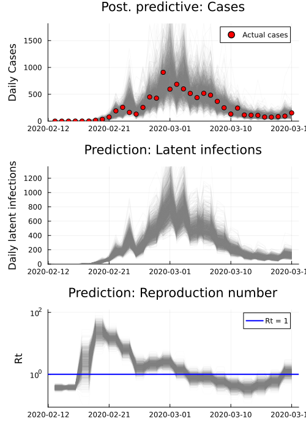

### Parameter inference

We can interrogate the sampled chains directly from the `samples` field of the `inference_results` object.

[figure not shown]